# Análisis de Ingresos CASEN 2022

Diego Llanculef

2025-04-21

# Introducción

El presente análisis busca evaluar la influencia de factores como el nivel educacional, la ocupación, la edad y el sexo sobre el ingreso per cápita en la Región Metropolitana, utilizando datos de la Encuesta CASEN 2022. Para ello, se aplicó un modelo de regresión lineal múltiple tras un proceso de limpieza y exploración de datos. Este modelo permite identificar qué variables tienen un efecto significativo en la variación del ingreso, aportando evidencia útil para el diseño de políticas públicas orientadas a la equidad social y económica.

**Hipótesis:** El nivel educacional y la ocupación de las personas son factores significativos para explicar las diferencias en el ingreso per cápita.

install.packages(“tidyverse”) install.packages(“corrplot”)

```r
# Librerias
library(tidyverse)
library(corrplot)
library(haven)
```

# Carga de Datos

```r
ruta_rds = "../data/casen_rm.rds" # "../" permite retroceder carpeta
casen_rm = readRDS(ruta_rds)
```

# Limpieza de Datos

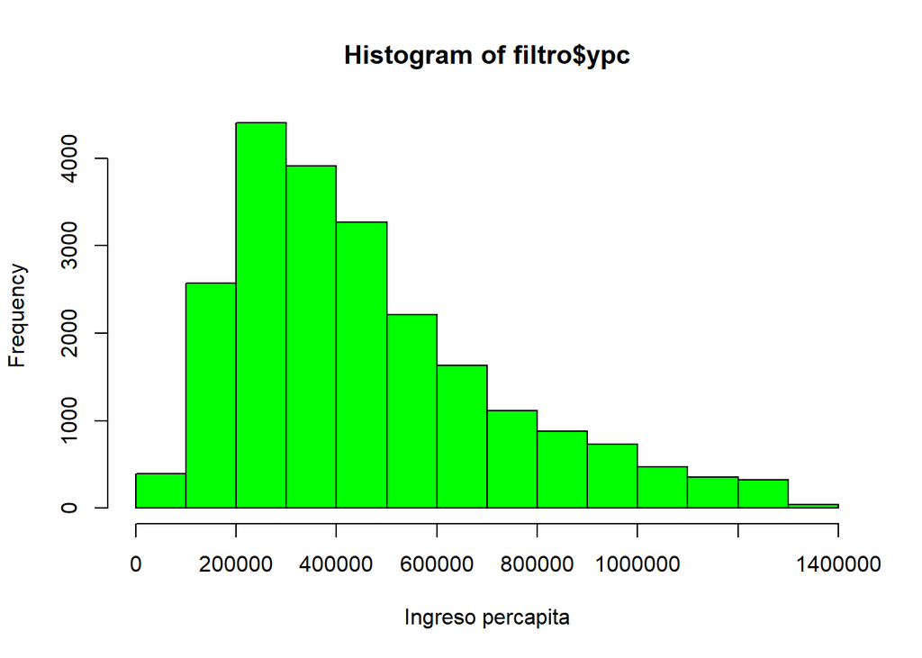

```r
# Reducción del umbral
umbral = quantile(casen_rm$ypc, 0.9, na.rm = TRUE)
filtro = casen_rm[casen_rm$ypc <= umbral & (casen_rm$edad >= 18) & (casen_rm$edad <= 65), ]

# Para evitar problemas con valores perdidos
filtro <- filtro %>%
  filter(!is.na(ypc), !is.na(edad), !is.na(sexo), !is.na(e6a), !is.na(o1))

# Histograma y boxplot luego de filtrar el ypc
hist(filtro$ypc, xlab = "Ingreso percapita", col = "green")
```

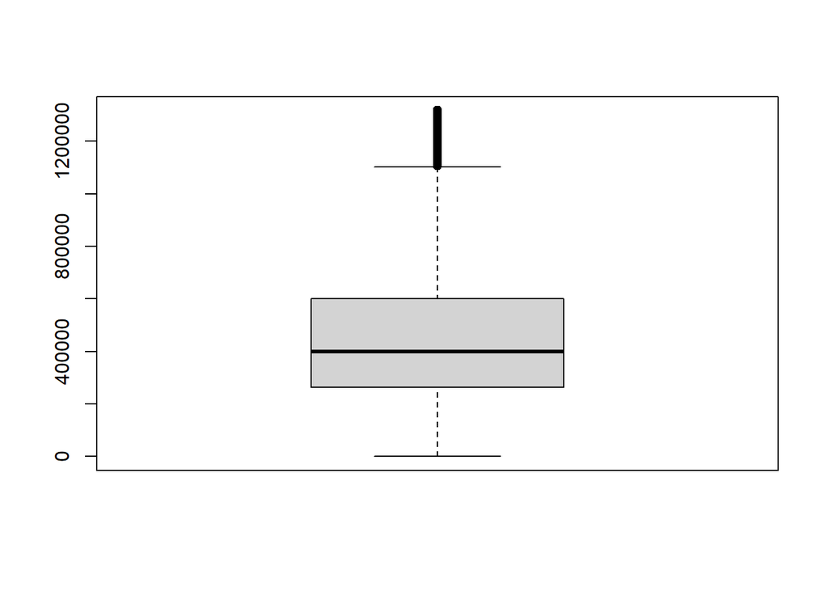

```r
boxplot(filtro$ypc)
```

# Selección de variable

```r
# Se seleccionan las variables claves para el estudio
# variable dependiente: Ingreso per cápita
# Variables independientes: Edad, Sexo, Nivel Educacional, Ocupación
datos <- casen_rm %>% select(ypc, edad, sexo, e6a, ocupacion = o1)

# En vez de usar las variables categoricas, es ideal convertirlas en factores para una mejor interpretación en el modelo
filtro$sexo <- as_factor(filtro$sexo)
filtro$e6a <- as_factor(filtro$e6a)
filtro$o1 <- as_factor(filtro$o1)
```

# Análisis Exploratorio

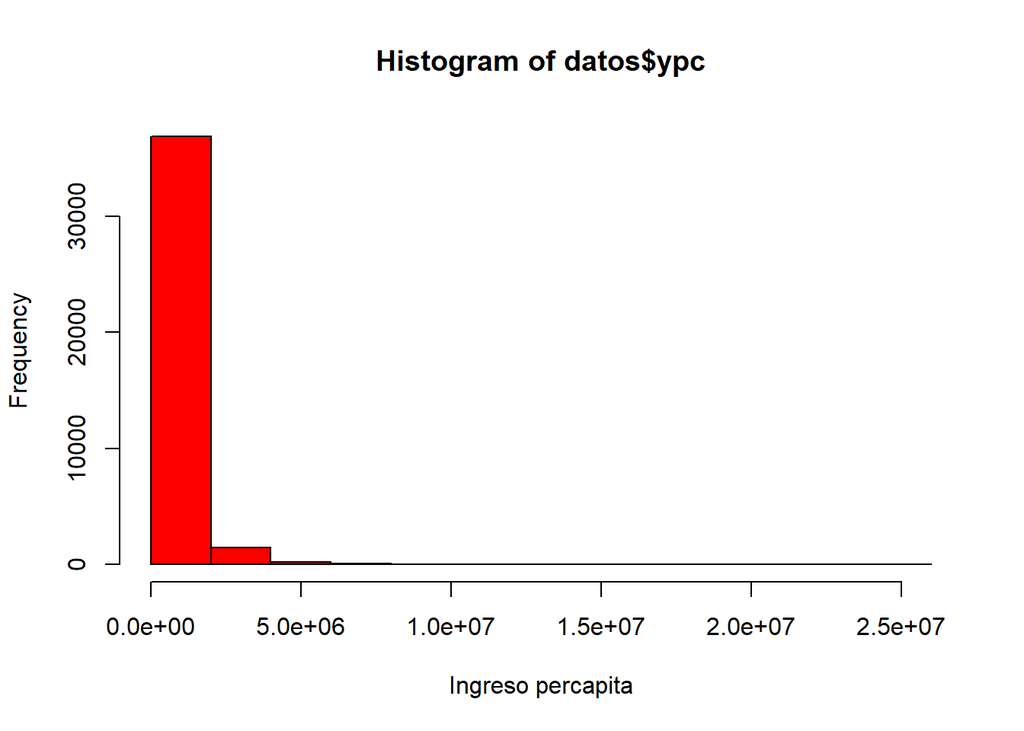

```r
#Para conocer la distribución de valores de cada variable se aplicaran histogramas, con el fin de determinar si estas presentan un comportamiento normal.

#Histograma y boxplot de YPC
hist(datos$ypc, xlab = "Ingreso percapita", col = "red")
```

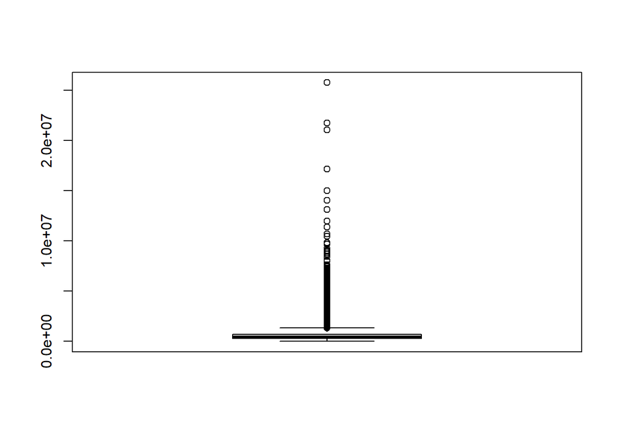

```r
boxplot(datos$ypc)
```

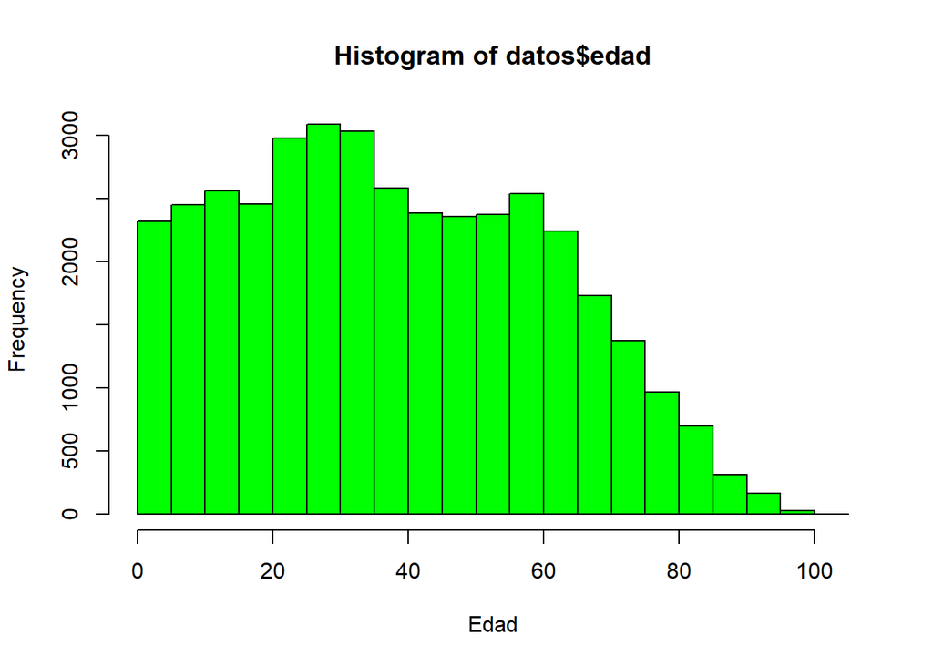

```r
# Histograma y bloxplot de Edad
hist(datos$edad, xlab = "Edad", col = "green")
```

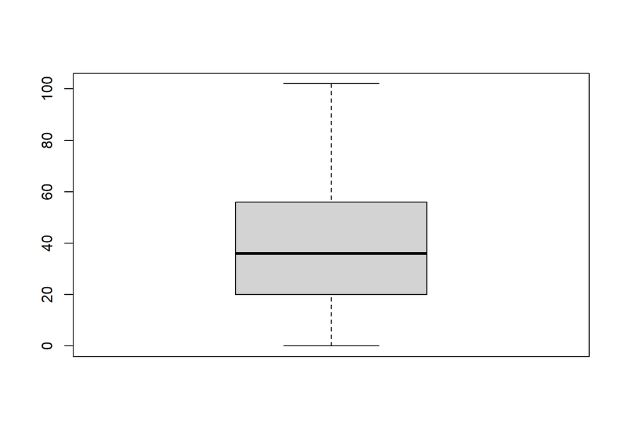

```r
boxplot(datos$edad)
```

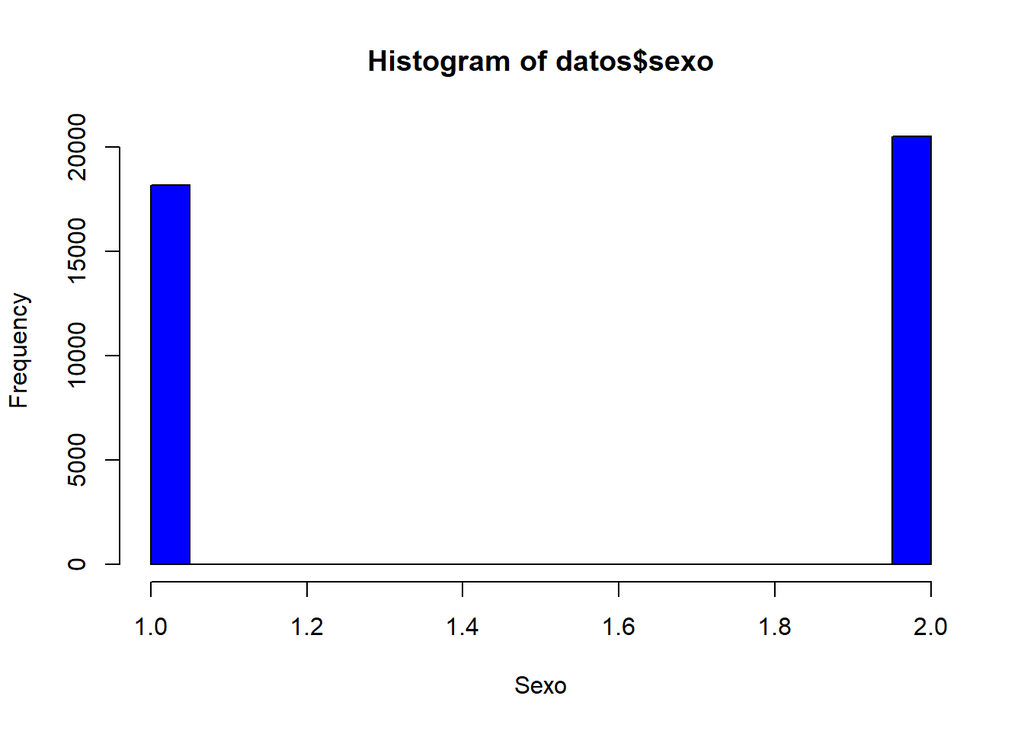

```r
# Histograma y bloxplot de Sexo
hist(datos$sexo, xlab = "Sexo", col = "blue")
```

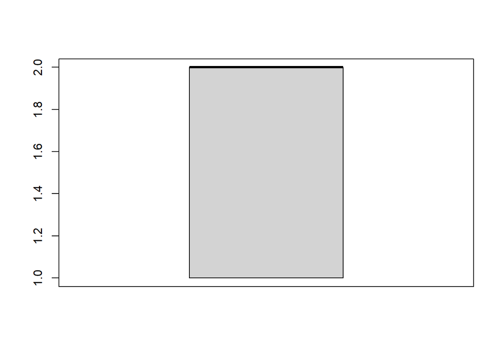

```r
boxplot(datos$sexo)
```

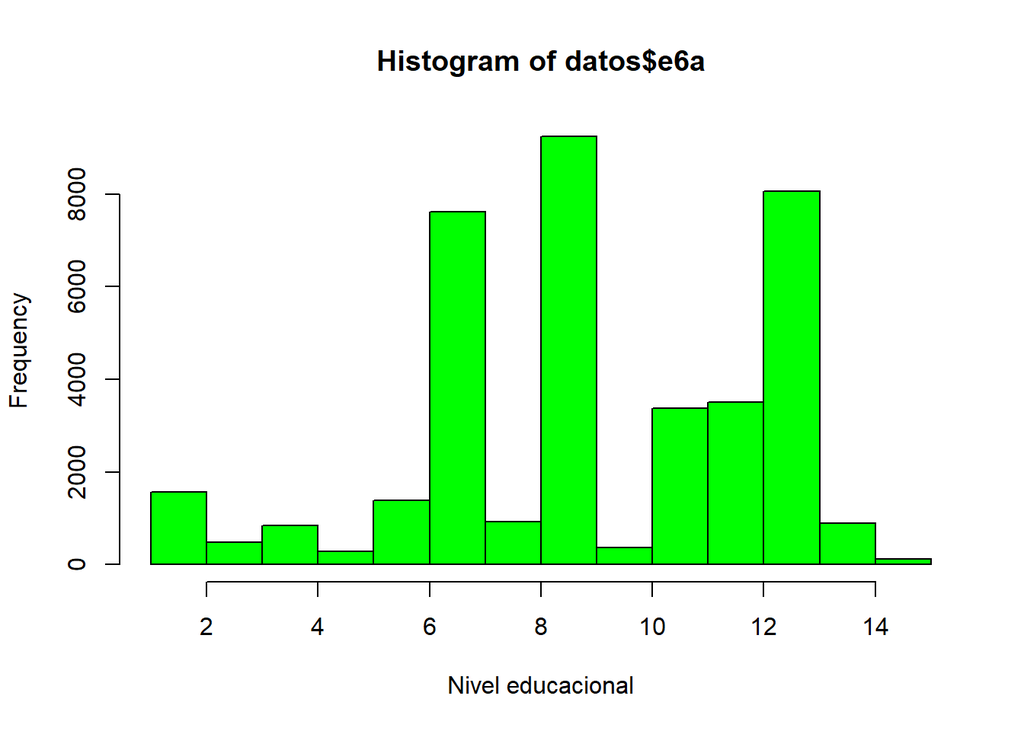

```r
# Histograma y bloxplot de Nivel educacional
hist(datos$e6a, xlab = "Nivel educacional", col = "green")
```

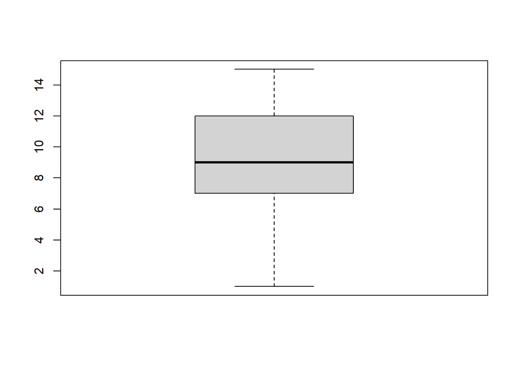

```r
boxplot(datos$e6a)
```

```r
# Histograma y bloxplot de Ocupación
datos$ocupacion <- as_factor(datos$ocupacion)
# Tabla de frecuencias
tabla_ocupacion <- table(datos$ocupacion)
print(tabla_ocupacion)
```

```
##
## 1. Sí 2. No
## 17214 14606
```

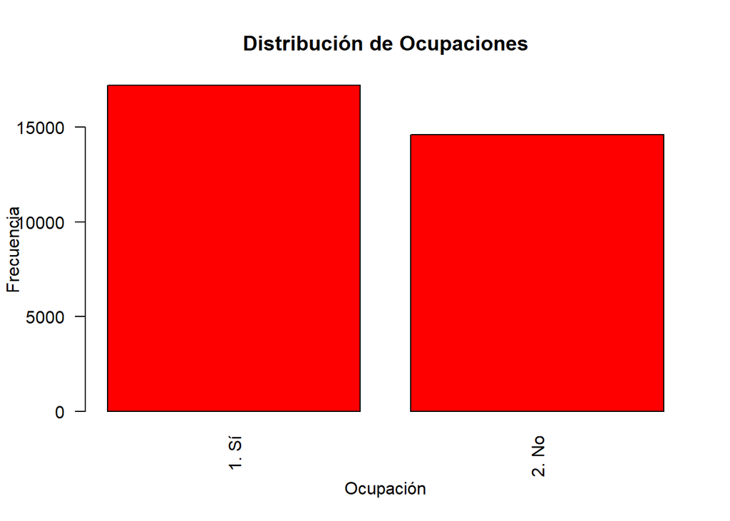

```r
# Gráfico de barras
barplot(tabla_ocupacion,
        las = 2,             # gira las etiquetas
        col = "red",
        xlab = "Ocupación",
        ylab = "Frecuencia",
        main = "Distribución de Ocupaciones")
```

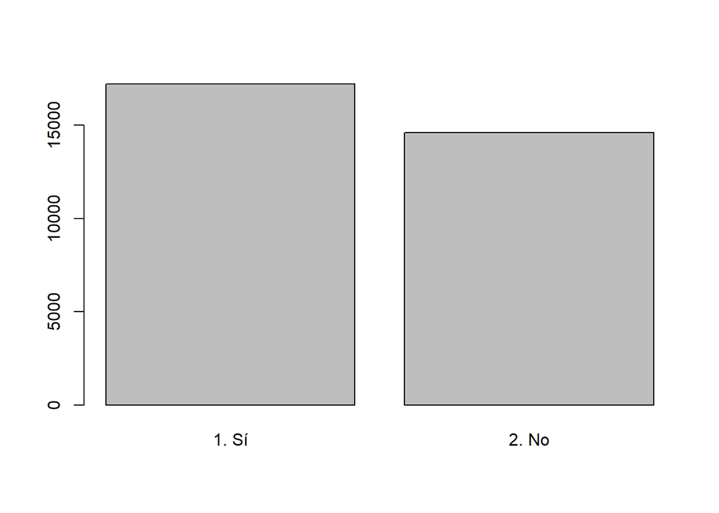

```r
barplot(table(datos$ocupacion))
```

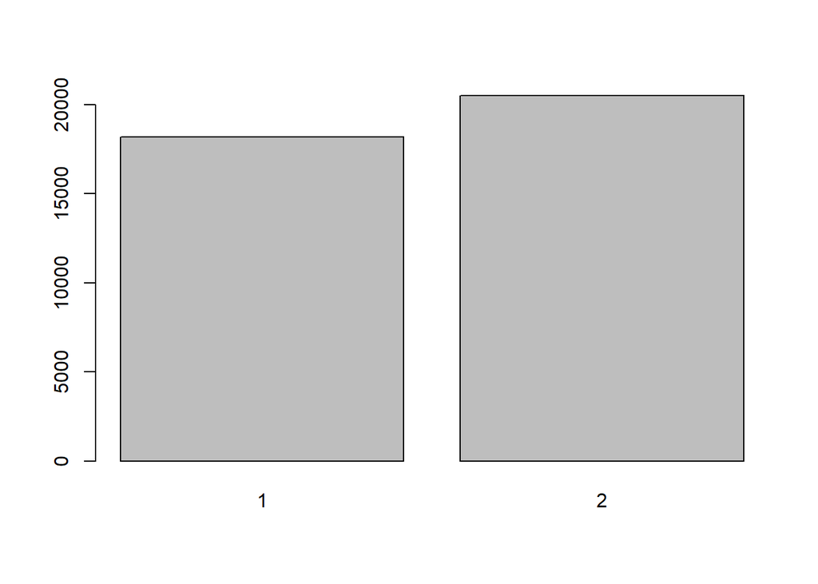

```r
barplot(table(datos$sexo))
```

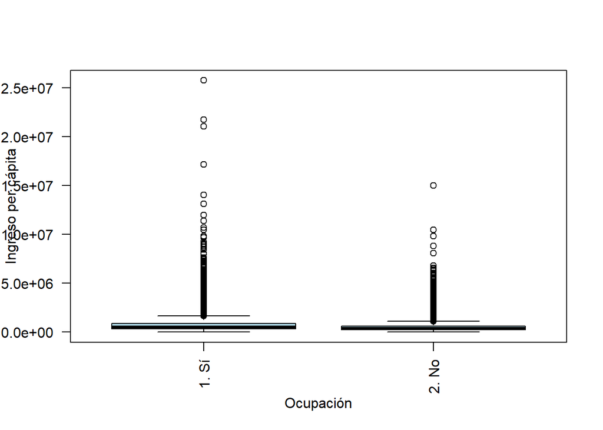

```r
#Como varia el ingreso segun la ocupación
boxplot(ypc ~ ocupacion, data = datos, col = "lightblue",
        xlab = "Ocupación", ylab = "Ingreso per cápita", las = 2)
```

# Correlación

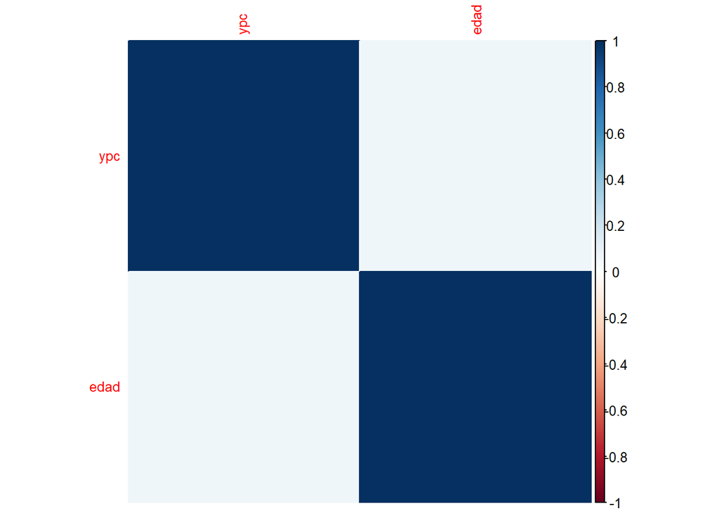

```r
# Se realiza la matriz de correlación solo entre ypc y edad
tabla_cor <- filtro %>% select(ypc, edad)
correlacion <- cor(tabla_cor, use = "complete.obs", method = "pearson")

# Visualización
corrplot(correlacion, method = "color", tl.cex = 0.8, number.cex = 0.7)
```

# Modelo de Regresión multiple

```r
modelo <- lm(ypc ~ edad + e6a + o1 + sexo, data = filtro)
summary(modelo)
```

```
##
## Call:
## lm(formula = ypc ~ edad + e6a + o1 + sexo, data = filtro)
##
## Residuals:
##     Min      1Q  Median      3Q     Max
## -848971 -165266  -42604  124429 1031686
##
## Coefficients:
##                                                                       Estimate
## (Intercept)                                                           218923.5
## edad                                                                    3280.7
## e6a4. Prekínder / Kínder (Transición menor y Transición Mayor)       -107942.2
## e6a5. Educación Especial (Diferencial)                                123397.9
## e6a6. Primaria o Preparatoria (Sistema antiguo)                        41893.1
## e6a7. Educación Básica                                                 18549.4
## e6a8. Humanidades (Sistema Antiguo)                                   101199.7
## e6a9. Educación Media Científico-Humanista                             84072.5
## e6a10. Técnica, Comercial, Industrial o Normalista (Sistema Antiguo)  173780.3
## e6a11. Educación Media Técnica Profesional                            104148.6
## e6a12. Técnico Nivel Superior (Carreras 1 a 3 años)                   206713.2
## e6a13. Profesional (Carreras 4 o más años)                            299674.7
## e6a14. Magíster o maestría                                            479135.4
## e6a15. Doctorado                                                      403753.7
## o12. No                                                               -97901.3
## sexo2. Mujer                                                          -14263.2
##                                                                      Std. Error
## (Intercept)                                                             24416.0
## edad                                                                      126.3
## e6a4. Prekínder / Kínder (Transición menor y Transición Mayor)         121964.0
## e6a5. Educación Especial (Diferencial)                                  31358.1
## e6a6. Primaria o Preparatoria (Sistema antiguo)                         32479.4
## e6a7. Educación Básica                                                  23831.4
## e6a8. Humanidades (Sistema Antiguo)                                     35679.3
## e6a9. Educación Media Científico-Humanista                              23588.3
## e6a10. Técnica, Comercial, Industrial o Normalista (Sistema Antiguo)    32765.3
## e6a11. Educación Media Técnica Profesional                              23853.5
## e6a12. Técnico Nivel Superior (Carreras 1 a 3 años)                     23863.9
## e6a13. Profesional (Carreras 4 o más años)                              23712.3
## e6a14. Magíster o maestría                                              27251.4
```

[output cut: 45 more lines]

```
## e6a9. Educación Media Científico-Humanista                           ***
## e6a10. Técnica, Comercial, Industrial o Normalista (Sistema Antiguo) ***
## e6a11. Educación Media Técnica Profesional                           ***
## e6a12. Técnico Nivel Superior (Carreras 1 a 3 años)                  ***
## e6a13. Profesional (Carreras 4 o más años)                           ***
## e6a14. Magíster o maestría                                           ***
## e6a15. Doctorado                                                     ***
## o12. No                                                              ***
## sexo2. Mujer                                                         ***
## ---
## Signif. codes:  0 '***' 0.001 '**' 0.01 '*' 0.05 '.' 0.1 ' ' 1
##
## Residual standard error: 239400 on 22269 degrees of freedom
## Multiple R-squared:  0.1948, Adjusted R-squared:  0.1942
## F-statistic: 359.1 on 15 and 22269 DF,  p-value: < 2.2e-16
```

# Análisis de Resultados

Los resultados del modelo de regresión muestran que la edad, el nivel educacional superior, la ocupación y el sexo tienen un efecto estadísticamente significativo sobre el ingreso per cápita, con p-valores menores a 0.05. Esto indica que estas variables influyen de manera real y no aleatoria en las diferencias de ingresos observadas entre las personas. En cuanto a la edad, se observa que por cada año adicional, el ingreso per cápita aumenta en promedio $3.280, manteniendo constantes las demás variables. Este efecto, aunque moderado, es altamente significativo, lo que sugiere que la experiencia laboral asociada a la edad puede estar siendo valorada en el mercado. Respecto a la educación, los niveles más altos presentan una relación positiva y significativa con el ingreso. Por ejemplo, quienes tienen estudios profesionales o de posgrado (magíster o doctorado) muestran ingresos considerablemente más altos, con incrementos promedio que superan los $300.000 y $400.000 en comparación con personas sin educación formal. En contraste, niveles educativos bajos como Prekínder/Kínder, Educación Básica o Primaria no presentan efectos estadísticamente significativos (p > 0.05), lo cual sugiere que estos niveles no representan una ventaja comparativa relevante en términos de ingreso. La ocupación resulta ser una variable crítica: las personas sin ocupación activa ganan en promedio $97.901 menos que quienes están ocupadas, y este efecto es altamente significativo (p < 0.001). Esto refleja la profunda desigualdad de ingresos entre quienes participan en el mercado laboral y quienes no.

Finalmente, el sexo también muestra un efecto significativo: ser mujer se asocia con una reducción promedio de $14.263 en el ingreso per cápita, incluso después de controlar por edad, nivel educativo y ocupación. Este resultado evidencia una brecha de género persistente en los ingresos, lo que pone en relieve la necesidad de políticas que fomenten la equidad laboral entre hombres y mujeres.

## Conclusiones

En este sentido, el modelo constituye una herramienta de análisis inicial que puede ser ampliada con la incorporación de otras variables relevantes, tales como pertenencia a pueblos originarios, situación de discapacidad, composición del hogar, zona urbana o rural, y región del país. La inclusión de estos factores permitiría mejorar la capacidad explicativa del modelo y entregar una visión más integral de las desigualdades de ingreso en Chile.

El análisis muestra con claridad que invertir en educación, especialmente en niveles técnicos y profesionales, está fuertemente asociado a mayores niveles de ingreso. Además, variables como la participación laboral y el género siguen teniendo un peso considerable en la desigualdad de ingresos. Estos hallazgos subrayan la importancia de considerar factores estructurales en el diseño de políticas públicas enfocadas en el acceso equitativo al empleo y la educación de calidad, así como en la reducción de brechas de género en el mercado laboral.